01 / WHO WAS ROSENBLATT

# Frank Rosenblatt (1928–1971)

심리학으로 출발해 수학·전자회로·컴퓨터로 ‘학습하는 뇌’를 구현한 연구자

1928.7.11

미국 뉴욕주 뉴로셸 출생 · Bronx High School of Science 졸업(1946)

1950

Cornell University 학사(A.B.) · 사회심리학 전공

1955

시지각 연구: Gibson·Olum·Rosenblatt, 항공기 착륙 시의 시차·원근지각 논문

1956

Cornell 심리학 박사(Ph.D.) · 다변량 분석의 K-coefficient 박사학위 논문

1955–1971

Cornell Aeronautical Laboratory → 인지시스템 연구책임 → Cornell 신경생물학 부교수

주의: Frank의 별도 ‘수학 석사논문’은 확인되지 않음. 수학 석사(1947)·박사(1949)는 동명이인 Murray Rosenblatt의 이력이다.

[figure not shown]

F R  
1928 — 1971

1958년 Rosenblatt(왼쪽)와 Wightman의 실험 장면 · Cornell University Archives

1971년 43번째 생일에 사고로 별세

02 / CAREER & PAPERS

# 그의 연구는 왜 심리학에서 시작했을까?

1955

### 시각적 지각 연구

Parallax and Perspective during Aircraft Landings  
비행기 착륙 상황에서 사람이 거리와 운동을 어떻게 지각하는가?

The American Journal of Psychology

1956

### K-coefficient 박사학위 논문

The k-Coefficient: Design and Trial Application of a New Technique for Multivariate Analysis  
심리측정 데이터를 분석하기 위해 EPAC 컴퓨터도 제작

Cornell Ph.D. in Psychology

1957–58

### 학습하는 기계의 원리

1957년 퍼셉트론 기술보고서 → 1958년 Psychological Review 논문  
기억을 데이터 저장이 아니라 연결의 변화로 모델링

Cornell Aeronautical Laboratory

1962

### Principles of Neurodynamics

수학적 분석, 학습 규칙, 다양한 퍼셉트론 구조를 집대성한 연구서

Book

한 줄 해석: 뇌의 지각과 기억이라는 심리학의 문제를 ‘계산하고 검증할 수 있는 기계’로 바꾸었다.

03 / K-COEFFICIENT

# 퍼셉트론 이전: 심리학 데이터를 수학으로 풀다

1956

**The k-Coefficient: Design and Trial Application of a New Technique for Multivariate Analysis**Cornell University · 심리학 박사학위 논문 · 수학 석사학위 논문이 아님

201명 × 약 600문항

학생의 가정환경, 어린 시절의 가족관계, 성격·행동은 서로 어떻게 연결될까?

서로 관련된 변수가 많아질수록  
**관계를 함께 분석하는 일이 어려워진다.**

K-coefficient는 복잡한 변수들의 연관성을 분석하려고 고안한 통계기법으로, 현대의 신경망 가중치와는 다른 개념이다.

연구 설계의 핵심 흐름 · 교육용 재구성

1

**설문 응답 수집**

201명의 여러 성격·가족관계 문항을 종이 설문으로 기록

2

**EPAC에서 응답쌍 비교**

입력 패턴의 차이에 기초한 D² 중간 계산값 생성

3

**후속 컴퓨터로 K 분석**

범용 컴퓨터를 이용해 관계를 통계적으로 평가

검증의 한계: K-coefficient가 기존 요인분석보다 우수하다는 것은 충분히 입증되지 않았다. 비선형 관계 검증과 허위 상관 문제도 남았다.

04 / EPAC → PERCEPTRON

# 계산하는 컴퓨터에서 학습하는 컴퓨터로

EPAC1951–1953

INPUT

D² OUTPUT

1953년 EPAC의 형태를 단순화한 개념도 · 실제 사진: [Cornell University 자료](https://as.cornell.edu/news/professors-perceptron-paved-way-ai-60-years-too-soon)

초당 25개 항목 판독진공관·네온 표시42가지 출력 상태

EPAC의 데이터 처리 구조

DATA**연필로 작성한 설문지**

사람들의 응답을 숫자와 패턴으로 입력

↓

HARDWARE**EPAC : 응답쌍의 D² 계산**

미리 설계한 회로와 연산 규칙이 고정

↓

STATISTICS**IBM 등 범용 컴퓨터**

후속 K-coefficient 분석과 검증

**EPAC (1953)**입력 데이터가 달라져도 계산 규칙은 그대로

→

**Perceptron (1958)**경험·강화에 따라 내부 연결의 효과가 달라진다

역사적 해석: 두 연구는 통계적 사고와 하드웨어 구현이라는 방법론에서 연결된다. K-coefficient 수식이 퍼셉트론 학습식으로 직접 전환된 것은 아니다.

05 / ORIGINAL PAPER

# 1958년 논문의 출발점: 어떻게 기억하는가?

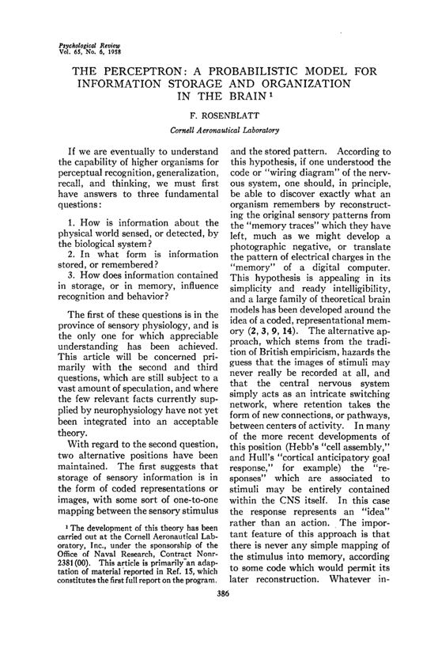

PSYCHOLOGICAL REVIEW · VOL. 65, NO. 6

## The Perceptron: A Probabilistic Model for Information Storage and Organization in the Brain

단순한 ‘이미지 분류 알고리즘’ 논문이 아니라, *기억·학습·인식의 물리적 작동 원리*를 확률과 신경회로로 설명한 논문

F. Rosenblatt · 1958 · pp. 386–408 · DOI: 10.1037/h0042519

06 / THE THREE QUESTIONS

# Rosenblatt이 던진 세 가지 질문

01

## 감각

우리는 바깥세상의 정보를 어떻게 받아들이는가?

SENSING

02

## 기억

받아들인 정보가 뇌에 어떤 형태로 저장되는가?

STORAGE

03

## 행동

과거의 경험이 다음 인식과 행동을 어떻게 바꾸는가?

RECOGNITION & BEHAVIOR

이 논문은 특히 두 번째 ‘기억’과 세 번째 ‘인식·행동’ 문제에 집중한다.

07 / TWO HYPOTHESES

# 기억은 ‘저장된 사진’인가, ‘바뀐 연결’인가?

가설 A · 정보의 복제

## 저장 후 비교

입력**→**메모리 사본**→**비교

정보를 내부에 복사해 두고, 다음 입력이 들어오면 저장된 표상과 대조한다.

비유: 저장된 사진과 새 사진을 하나씩 대조

가설 B · 연결주의

## 연결의 변화

입력**→**연결 변화**→**반응

특정 경험 후 뉴런 사이의 연결 강도가 변하고, 다음 입력에 대한 반응이 달라진다.

비유: 반복해서 연습하면 익숙한 길로 손이 움직임

Rosenblatt의 선택: B. 학습은 ‘파일 저장’이 아니라 ‘회로의 변형’으로 이해할 수 있다.

08 / ORIGINAL ARCHITECTURE

# 원문 Fig. 1: 눈 → 연합 뉴런 → 반응

S

### Sensory

망막·센서로부터 입력 수집

→

A

### Association

여러 입력의 조합에 반응 · 연결 강도 변화

→

R

### Response

분류 결과 혹은 행동 선택

○△

### 학습이란 무엇이 바뀌는가?

모델 전체가 바뀌는 것이 아니라, 특정 연합 뉴런의 영향력과 연결이 조정되어 **같은 입력에 대한 다음 반응**이 달라진다.

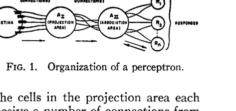

1958 원문 Fig. 1

09 / HOW ONE UNIT WORKS

# 뉴런 하나의 판단은 의외로 단순하다

x₁형태 특성

x₂밝기 특성

x₃윤곽 특성

w₁

w₂

w₃

Σ

→

### 문턱값 비교

합이 기준보다 크면 1, 아니면 0

출력 y = 1 if (w₁x₁ + w₂x₂ + w₃x₃ + b) ≥ 0, else 0

이 표기는 학생 이해를 위한 현대적 단순화입니다. 1958년 논문 전체 구조와 완전히 같은 식은 아닙니다.

핵심은 덧셈이 아니라 ‘가중치가 경험을 통해 바뀐다’는 것이다.

10 / A LEARNING LOOP

# 틀리면 고친다: 학습의 한 사이클

01

## 입력

새 패턴을 보여준다

›

02

## 판단

현재 연결로 답을 고른다

△ ?

›

03

## 피드백

맞는지 확인한다

오답

›

04

## 수정

다음에는 정답 쪽 연결을 강화

Δw

반복할수록 모형의 연결 상태가 바뀐다. 처음부터 사람이 모든 분류 규칙을 코딩할 필요가 없다.

11 / INTERACTIVE EXAMPLE

# 직접 체험: 한 번의 오류가 가중치를 바꾼다

1. 입력을 선택하세요

문제: 두 신호가 모두 1일 때만 정답 1 (AND)

2. 예측 결과

0

목표값과 비교해 보세요.

w₁ = 0.10 · w₂ = 0.10 · b = -0.40 · 학습률 = 0.20교육용 단층 퍼셉트론 갱신식: w ← w + η(t − y)x

버튼을 눌러 입력값을 바꾸고 ‘학습 1회’를 반복해 보세요. 실제로는 여러 학습 샘플을 번갈아 보여줍니다.

12 / TWO PHASES

# 원문 Fig. 3: 잠깐 경쟁하고 하나가 선택된다

PHASE 1

## Predominant phase

여러 연합 뉴런(A)이 동시에 자극받고, 아직 특정 반응(R)이 완전히 정해지지 않은 상태

PHASE 2

## Postdominant phase

한 반응이 우세해지고, 경쟁하는 다른 반응을 억제해 결과가 선택되는 상태

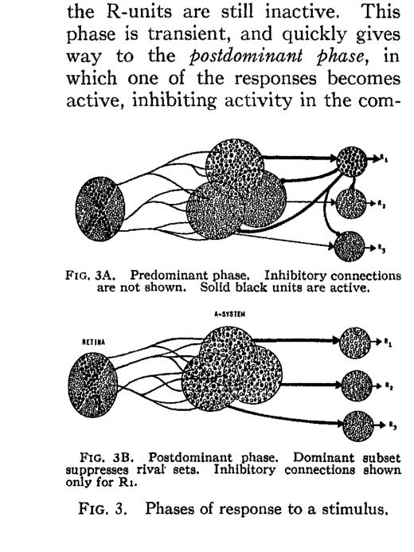

원문 Fig. 3A, 3B · 활성화된 뉴런과 억제 연결 표시

핵심: 퍼셉트론은 단순히 직선을 그리는 계산만이 아니라, 생물학적 경쟁·억제 회로를 다룬 모델이었다.

13 / PROBABILISTIC THINKING

# 왜 제목에 ‘확률 모델’이 들어갔을까?

Pₐ

## 반응할 확률

하나의 입력 자극이 들어왔을 때 어떤 A-뉴런이 활성화될 확률

P꜀

## 함께 반응할 확률

입력 1에 반응한 A-뉴런이 입력 2에도 반응할 조건부 확률

자극 1

자극 2

모든 연결의 정확한 배선을 몰라도, ‘얼마나 많이 켜지는지’와 ‘두 입력의 반응이 얼마나 겹치는지’로 학습을 예측한다.

14 / THE IMPORTANT INEQUALITY

# 논문의 핵심: 같은 종류는 비슷하게 반응해야 한다

같은 부류끼리의 반응 겹침은 높고, 서로 다른 부류끼리의 겹침은 낮아야 일반화가 가능하다.

### ○ 와 ○

같은 클래스 · 많은 뉴런이 함께 반응

P<sub>c11</sub> 높음

### ○ 와 □

다른 클래스 · 반응 겹침은 작아야 함

P<sub>c12</sub> 낮음

학생용 번역: 같은 종류끼리는 닮게, 다른 종류끼리는 다르게 표현할수록 처음 보는 데이터도 구분할 수 있다.

15 / MEMORIZATION vs GENERALIZATION

# 외우는 것과 이해하는 것은 다르다

기억 / Recognition

## 전에 본 패턴에 정답

학습 중 본 자극에 올바른 반응을 보이는지 평가: Pᵣ

일반화 / Generalization

## 처음 보는 변형에도 정답

위치·크기·회전이 바뀐 새 자극에도 올바른 반응을 보이는지 평가: Pᵍ

원문은 학습 때 보았던 입력과 새로 등장한 입력을 분리해 성능을 평가한다. 오늘날 훈련 정확도와 테스트 성능의 구별과 연결된다.

16 / EMPIRICAL / THEORETICAL CURVES

# 원문 Fig. 11: 경험이 쌓이면 일반화가 좋아진다

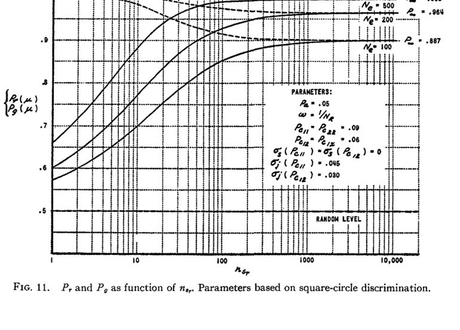

원문 Fig. 11 · 사각형과 원의 구분 문제를 이용한 학습 곡선

01

### 가로축

학습한 자극의 수

02

### 세로축

올바른 반응을 보일 확률

03

### 읽을 메시지

유사한 패턴을 학습한 결과, 보지 못한 새 패턴에 대한 일반화 확률도 높아질 수 있다. 모델 매개변수마다 상한은 달라진다.

중요: 원문의 곡선은 조건을 정한 이론·모델 결과이며, 현대 신경망 전체의 보편 성능 곡선이 아니다.

17 / THREE UPDATE SYSTEMS

# 원문 Table 1·Fig. 10: 학습 규칙도 비교했다

α

### 계속 누적

활성 뉴런이 경험할수록 값이 증가한다. 편리하지만 값이 계속 커질 수 있다.

β

### 총 증가량 제한

한 응답 집합의 가치 증가분을 일정하게 제한해 분배한다.

γ

### 경쟁적 재분배

활성 뉴런이 얻는 만큼 비활성 뉴런의 값이 감소해 총량을 유지한다.

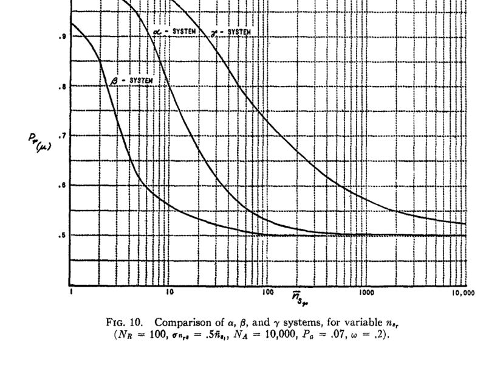

Fig. 10에서는 특정 가정 아래 γ 계열이 유리한 사례를 보여준다. 세 방식 중 어느 것이 항상 최선이라는 뜻은 아니다.

18 / DISTRIBUTED MEMORY

# 뇌의 기억은 한 뉴런에만 들어있지 않다

연합 시스템 전체에 분산된 기억

## 어떤 일부가 손상되어도 바로 모든 기억이 사라지지 않는다

1958년 논문은 한 연합이 많은 세포에 걸쳐 분산될 수 있으며, 일부 제거는 한 특정 기억의 완전한 소실보다는 여러 학습 결과의 전반적 성능 저하로 나타날 수 있다고 설명한다.

하나의 단일 ‘저장 셀’보다, 전체 네트워크의 가중치 패턴에 정보가 담긴다는 생각

신경망이 가진 매력: 여러 뉴런의 공동 표현과 부분 손상에 대한 견고성.

19 / LIMITS

# Rosenblatt 자신도 모델의 한계를 분명히 적었다

“사각형 왼쪽에 있는 물체를 가리켜라.”

물체 한 개의 특징이 아니라 둘 사이의 ‘관계’를 판단해야 한다.

## 단순한 통계적 분리만으로는 관계의 추상화가 어렵다.

논문은 시간·공간적 관계를 해석하는 고차 추상화에서 퍼셉트론이 어려움을 겪을 수 있다고 직접 인정한다.

오늘날 다층 신경망은 여러 단계의 표현을 조합해 복잡한 관계를 학습하려 하지만, 모델의 구조와 데이터에 따라 여전히 실패할 수 있다.

학문적 교훈: 최초 제안자의 원문에도 가능성과 한계가 함께 기록되어 있다.

20 / HISTORICAL INTERPRETATION

# 자주 생기는 오해 세 가지

“1958년에 지금의 역전파가 발명됐다.”

아니다. 현대적 다층망의 역전파와 동일시하면 역사적으로 부정확하다.

“퍼셉트론은 그저 선형 분류기였다.”

현대 교과서의 단층 모델은 유용한 축약이다. 원문은 확률적 연결, 여러 A-단계, 억제·피드백, 기억과 일반화 등 더 넓은 모델군을 논의한다.

“XOR를 못 하니 신경망 연구는 틀린 방향이었다.”

XOR는 기본 선형 임계 분류기의 한계를 보여주는 예다. 이를 Rosenblatt의 전체 연구가 무의미했다는 증거로 확대해서는 안 된다.

21 / MODERN ML BRIDGE

# 1958년과 오늘날의 딥러닝을 잇는 다리

1958

## Perceptron

뉴런의 연결, 강화, 반응 겹침, 일반화의 가능성을 확률적으로 분석

S → A → R

→

TODAY

## Deep Neural Network

대량 데이터로 다층 표현을 학습하고 손실함수와 최적화 기법으로 가중치를 조정

Input → Features → Output

**두 시대를 관통하는 하나의 생각**

경험을 통해 내부 연결이 조정되고, 그 결과 아직 보지 못한 입력에 대한 예측이 개선될 수 있다.

22 / CLASSROOM APPLICATION

# 반도체 데이터에서 이 논문을 어떻게 활용할까?

01

### 입력 특성

공정센서의 온도·압력·전류 값이 S 입력 역할

02

### 학습된 표현

정상/불량을 구분할 수 있는 유효한 특성과 결합을 학습

03

### 출력

양품/불량 예측 R, 또는 불량 가능성 점수

04

### 진짜 성능

새 웨이퍼·새 로트에서도 맞는가? 시간·로트별 검증 필요

## 토론: 훈련 정확도 99%라면 반도체 불량 예측도 99% 신뢰할 수 있을까?

불량 비율, 공정 시점 차이, 데이터 누출, 장비·로트 변화를 고려해야 한다. Rosenblatt의 ‘일반화’ 문제는 지금도 유효하다.

23 / TAKEAWAYS

# 이 논문에서 반드시 기억할 네 가지

1

퍼셉트론은 원래 *뇌의 학습과 기억을 설명*하려는 심리학적·생물학적 모형이다.

2

경험은 정답표가 아니라 *뉴런 연결의 변화*로 축적될 수 있다.

3

진짜 학습은 이미 본 입력에 대한 기억을 넘어 *새 입력에 대한 일반화*를 보여야 한다.

4

Rosenblatt는 *관계·추상화의 한계*까지 스스로 제시했다. 이것이 다음 세대 연구의 출발점이다.

AI의 출발점은 복잡한 코드가 아니라 “기계도 경험으로부터 배울 수 있는가?”라는 질문이었다.

24 / ORIGINAL SOURCES

# 참고 문헌과 사실 확인 자료

01

### Rosenblatt (1958) · 원문

The Perceptron: A Probabilistic Model for Information Storage and Organization in the Brain. Psychological Review, 65(6), 386–408.

doi.org/10.1037/h0042519

02

### Cornell University · 공식 추모문

Frank Rosenblatt (1928–1971), Cornell Faculty Memorial Statement. 학위와 경력, 사망 사실의 일차 자료.

[Cornell Memorial PDF](https://ecommons.cornell.edu/bitstream/handle/1813/18965/Rosenblatt_Frank_1971.pdf)

03

### George Nagy (2011) · 제자의 학술 회고

Frank Rosenblatt, My Distinguished Advisor. 1955년 연구논문, 1956년 박사논문, 장비와 알고리즘 자료.

[발표자료 PDF](https://sites.ecse.rpi.edu/~nagy/PDF_chrono/2011_Nagy_Pace_FR.pdf)

04

### Cornell Chronicle (2019) · 사진·생애

Professor’s perceptron paved the way for AI – 60 years too soon.

[Cornell Chronicle](https://news.cornell.edu/stories/2019/09/professors-perceptron-paved-way-ai-60-years-too-soon)

05

### Gibson, Olum & Rosenblatt (1955)

Parallax and Perspective during Aircraft Landings. American Journal of Psychology, 68(3), 372–385.

doi.org/10.2307/1418521

06

### Murray Rosenblatt · 별도 수학자

동명이인. Cornell 수학 석사(1947)·박사(1949) — Frank의 학위와 구분.

[Murray Rosenblatt CV](https://celebratio.org/Rosenblatt_M/article/949/)

1 / 24